# **The World Cup soccer game prediction using machine learning method**

Once four year! Everyone loves the World Cup.

The **machine learning and data science methods** are developing very fast recent years, why not trying to **predict the World Cup game** result using the method?

Too difficult? After this project, **everyone can do it**! Too technical required? We have **everything prepared** in this project! I can't understand all? Welcome back and you can review it **whenever you want**! Only soccer, any other sports? The idea is the same, you could **easily extend** the method to any other sports.

[figure not shown]

We understand that sports game are highly uncertainted, but the forcast result could tell a lot of information that could help! Moreover, the more information used in the model, the more precise the models can predict. We only use a part of the data that we provided. You can add all the data or even collect your own data for a more robust prediction model.

1. Objectives
2. Setup
   1. Installing Required Libraries
   2. Importing Required Libraries
   3. Defining Helper Functions
3. Background and preparation for the model
   1. How should we collect and deal with the data?
   2. How the stucture of the machine learning model to predict soccer games should be like?
4. Training and prediction
   1. Train the model
   2. Predicting the game
   3. Analyze the model
5. Exercises
   1. Exercise 1 - Showing a specific player data
   2. Exercise 2 - Display a team line up in one game
   3. Exercise 3 - Showing a specific game result prediction

## Objectives

After completing this lab, you will be able to:

- **Know** how to collect and prepare data for a data-driven project
- **Understand** how to predict sports result using machine learning models
- **Implement** for the World cup game prediction using a simple neural network model

## Setup

For this lab, we will be using the following libraries:

- `pandas` for managing the data.
- [`numpy`](https://numpy.org/?utm_medium=Exinfluencer&utm_source=Exinfluencer&utm_content=000026UJ&utm_term=10006555&utm_id=NA-SkillsNetwork-Channel-SkillsNetworkCoursesIBMML0187ENSkillsNetwork31430127-2021-01-01) for mathematical operations.
- `sklearn` for machine learning and machine-learning-pipeline related functions.
- `seaborn` for visualizing the data.
- [`matplotlib`](https://matplotlib.org/?utm_medium=Exinfluencer&utm_source=Exinfluencer&utm_content=000026UJ&utm_term=10006555&utm_id=NA-SkillsNetwork-Channel-SkillsNetworkCoursesIBMML0187ENSkillsNetwork31430127-2021-01-01) for additional plotting tools.

### Installing Required Libraries

The following required libraries are **not** pre-installed in the Skills Network Labs environment. **You will need to run the following cell** to install them:

*It will take ~30 second to install the libraries.*

libraries required:

> lime

> shap

> skillsnetwork

### Importing Required Libraries

*We recommend you import all required libraries in one place (here):*

*It will take ~30 second to import the libraries.*

```python
import numpy as np
import pandas as pd
from itertools import accumulate
import matplotlib.pyplot as plt
%matplotlib inline
from sklearn.preprocessing import StandardScaler
from sklearn.datasets import load_digits, load_wine
from sklearn.model_selection import train_test_split
from sklearn import preprocessing
from sklearn.neural_network import MLPClassifier
from sklearn.model_selection import GridSearchCV
from sklearn.metrics import accuracy_score
import lime
from lime import lime_tabular
import shap

# You can also use this section to suppress warnings generated by your code:
def warn(*args, **kwargs):
    pass
import warnings
warnings.warn = warn
warnings.filterwarnings('ignore')
```

```python
import skillsnetwork
```

### Defining Helper Functions

*Use this section to define any helper functions to help the notebook's code readability:*

```python
# This function will allow us to easily plot data taking in x values, y values, and a title
def plotter(x, y, title):
    plt.plot(x, y)
    plt.xlabel('X')
    plt.ylabel('Y')
    plt.title(title)
    plt.show()
```

## Background and preparation for the model

The World Cup 2022 is going to be held in Qatar. The World Cup is always popular all around the world. Here, we want to build a machine learning model which could predict the propbabilities of Win/Draw/Lose for every team in every game.

To build the machine learning model to predict soccer games, we should be able to:

**1. How should we collect the data**

**2. Determine the stucture of the machine learning model to predict soccer games**

[figure not shown]

### How should we collect and Analyse the Data?

Here, we want to quantify a game features used as an input to build the model to predict the game result. It is staright forward to think of quantifying the player who played the game. If we have the **quantified player (who played the games) data, game result**, then we can build the model.

__We limted the games used for training to the ones played between the *teams which will go to the World Cup* in _2022.___ because of the following reason:

(1) With the change of soccer game and player age growth, the same national teams' lineup can be totally different in every year.

(2) The decisive keys in a soccer game could also be different with the time passes, the most advanced soccer style are changing.

(3) The national teams which will play in the World Cup are mostly (Team like Italy could be the outliners) the strongest teams. The game style in the high-level (less weakest position determined) games and low-level (goal keeper determined) games are different.

#### Games for training

The following is all the national team game results in 2022. (from Kaggle https://www.kaggle.com/datasets/martj42/international-football-results-from-1872-to-2017)

```python
await skillsnetwork.download_dataset('https://cf-courses-data.s3.us.cloud-object-storage.appdomain.cloud/IND-GPXX0TUZEN/Training_games.csv')
print('file downloaded')
Game_all = pd.read_csv('Training_games.csv')
Game_all.head()
```

```
Saved as 'Training_games.csv'
file downloaded
```

|  | Unnamed: 0 | home_team | away_team | home_score | away_score | tournament | city | country | neutral |
| --- | --- | --- | --- | --- | --- | --- | --- | --- | --- |
| 0 | 2022-01-02 | Gabon | Burkina Faso | 0.0 | 3.0 | Friendly | Dubai | United Arab Emirates | True |
| 1 | 2022-01-02 | Sudan | Zimbabwe | 0.0 | 0.0 | Friendly | Yaoundé | Cameroon | True |
| 2 | 2022-01-03 | Rwanda | Guinea | 3.0 | 0.0 | Friendly | Kigali | Rwanda | False |
| 3 | 2022-01-04 | Mauritania | Gabon | 1.0 | 1.0 | Friendly | Dubai | United Arab Emirates | True |
| 4 | 2022-01-05 | Algeria | Ghana | 3.0 | 0.0 | Friendly | Al Rayyan | Qatar | True |

The teams list of the team in the World Cup 2022:

```python
#Team = pd.DataFrame({'team':['Senegal','Qatar','Netherlands','Ecuador','Iran','England','United States','Wales','Argentina','Saudi Arabia','Mexico','Poland','Denmark','Tunisia','France','Australia','Germany','Japan','Spain','Costa Rica','Morocco','Croatia','Belgium','Canada','Switzerland','Cameroon','Brazil','Serbia','Uruguay','Korea Republic','Portugal','Ghana']})
Teams = ['Senegal','Qatar','Netherlands','Ecuador','Iran','England','United States','Wales','Argentina','Saudi Arabia','Mexico','Poland','Denmark','Tunisia','France','Australia','Germany','Japan','Spain','Costa Rica','Morocco','Croatia','Belgium','Canada','Switzerland','Cameroon','Brazil','Serbia','Uruguay','Korea Republic','Portugal','Ghana']
```

Change the colunm name 'South Korea' to 'Korea Republic' to make the same name for each DataFrame:

```python
Game_all = Game_all.replace('South Korea','Korea Republic')
Game_all.head()
```

|  | Unnamed: 0 | home_team | away_team | home_score | away_score | tournament | city | country | neutral |
| --- | --- | --- | --- | --- | --- | --- | --- | --- | --- |
| 0 | 2022-01-02 | Gabon | Burkina Faso | 0.0 | 3.0 | Friendly | Dubai | United Arab Emirates | True |
| 1 | 2022-01-02 | Sudan | Zimbabwe | 0.0 | 0.0 | Friendly | Yaoundé | Cameroon | True |
| 2 | 2022-01-03 | Rwanda | Guinea | 3.0 | 0.0 | Friendly | Kigali | Rwanda | False |
| 3 | 2022-01-04 | Mauritania | Gabon | 1.0 | 1.0 | Friendly | Dubai | United Arab Emirates | True |
| 4 | 2022-01-05 | Algeria | Ghana | 3.0 | 0.0 | Friendly | Al Rayyan | Qatar | True |

Pick up the game played among the teams which will go to the World Cup 2022 (in Team list):

```python
Game_used = Game_all.drop(Game_all[(~Game_all['home_team'].isin(Teams)) | (~Game_all['away_team'].isin(Teams)) ].index)
Game_used.count()
Game_used
```

|  | Unnamed: 0 | home_team | away_team | home_score | away_score | tournament | city | country | neutral |
| --- | --- | --- | --- | --- | --- | --- | --- | --- | --- |
| 10 | 2022-01-10 | Morocco | Ghana | 1.0 | 0.0 | African Cup of Nations | Yaoundé | Cameroon | True |
| 72 | 2022-01-27 | Ecuador | Brazil | 1.0 | 1.0 | FIFA World Cup qualification | Quito | Ecuador | False |
| 87 | 2022-01-30 | Canada | United States | 2.0 | 0.0 | FIFA World Cup qualification | Hamilton | Canada | False |
| 88 | 2022-01-30 | Mexico | Costa Rica | 0.0 | 0.0 | FIFA World Cup qualification | Mexico City | Mexico | False |
| 100 | 2022-02-01 | Japan | Saudi Arabia | 2.0 | 0.0 | FIFA World Cup qualification | Saitama | Japan | False |
| ... | ... | ... | ... | ... | ... | ... | ... | ... | ... |
| 709 | 2022-09-27 | Ecuador | Japan | 0.0 | 0.0 | Kirin Challenge Cup | Düsseldorf | Germany | True |
| 715 | 2022-09-27 | Iran | Senegal | 1.0 | 1.0 | Friendly | Maria Enzersdorf | Austria | True |
| 717 | 2022-09-27 | Korea Republic | Cameroon | 1.0 | 0.0 | Friendly | Seoul | Korea Republic | False |
| 727 | 2022-09-27 | Saudi Arabia | United States | 0.0 | 0.0 | Friendly | Murcia | Spain | True |
| 731 | 2022-09-27 | Portugal | Spain | 0.0 | 1.0 | UEFA Nations League | Braga | Portugal | False |

62 rows × 9 columns

Here are the 62 games are going to be used in training.

We are making sure every team go to the world cup is in the training set:

```python
list3 = list(Game_used['home_team'].unique()) + list(set(Game_used['away_team'].unique()) - set(Game_used['home_team'].unique()))
list(set(list3) - set(Teams))
```

```
[]
```

#### Players for training

As we introduced, we are using the line up of the team as the input of the training dataset. Thus, we need the player dataset.

The FIFA sponsored most recent EA soccer game FIFA23 is a good source for the players' detailed data. Thus, we are using the FIFA23 player data. The data can be download from Kaggle (https://www.kaggle.com/datasets/cashncarry/fifa-23-complete-player-dataset)

[figure not shown]

```python
await skillsnetwork.download_dataset('https://cf-courses-data.s3.us.cloud-object-storage.appdomain.cloud/IND-GPXX0TUZEN/Player.csv')
print('file downloaded')
Player_all = pd.read_csv('Player.csv')
Player_all.head()
```

```
Saved as 'Player.csv'
file downloaded
```

|  | Name | FullName | Age | Height | Weight | Nationality | Overall | Positions | PreferredFoot | IntReputation | ... | LMRating | CMRating | RMRating | LWBRating | CDMRating | RWBRating | LBRating | CBRating | RBRating | GKRating |
| --- | --- | --- | --- | --- | --- | --- | --- | --- | --- | --- | --- | --- | --- | --- | --- | --- | --- | --- | --- | --- | --- |
| 0 | L. Messi | Lionel Messi | 35 | 169 | 67 | Argentina | 91 | RW | Left | 5 | ... | 91 | 88 | 91 | 67 | 66 | 67 | 62 | 53 | 62 | 22 |
| 1 | K. Benzema | Karim Benzema | 34 | 185 | 81 | France | 91 | CF,ST | Right | 4 | ... | 89 | 84 | 89 | 67 | 67 | 67 | 63 | 58 | 63 | 21 |
| 2 | R. Lewandowski | Robert Lewandowski | 33 | 185 | 81 | Poland | 91 | ST | Right | 5 | ... | 86 | 83 | 86 | 67 | 69 | 67 | 64 | 63 | 64 | 22 |
| 3 | K. De Bruyne | Kevin De Bruyne | 31 | 181 | 70 | Belgium | 91 | CM,CAM | Right | 4 | ... | 91 | 91 | 91 | 82 | 82 | 82 | 78 | 72 | 78 | 24 |
| 4 | K. Mbappé | Kylian Mbappé | 23 | 182 | 73 | France | 91 | ST,LW | Right | 4 | ... | 92 | 84 | 92 | 70 | 66 | 70 | 66 | 57 | 66 | 21 |

5 rows × 71 columns

We can have a look at how many players are in every country among the 32 world cup attending ones.

```python
for i in range(len(Teams)):
    print(Teams[i],Player_all.loc[Player_all['Nationality'] == Teams[i]]['Name'].count())
```

```
Senegal 132
Qatar 30
Netherlands 428
Ecuador 176
Iran 16
England 1632
United States 437
Wales 164
Argentina 937
Saudi Arabia 331
Mexico 60
Poland 390
Denmark 318
Tunisia 31
France 963
Australia 275
Germany 1204
Japan 80
Spain 1074
Costa Rica 21
Morocco 106
Croatia 167
Belgium 318
Canada 82
Switzerland 218
Cameroon 76
Brazil 728
Serbia 103
Uruguay 278
Korea Republic 319
Portugal 382
Ghana 135
```

Some players who played the games in the training set are not included in the FIFA23 player dataset. We will substitute these players with similar players. The similarities will be based on the position, country, and matching skills.

We can have a look at the player's data, for example the Ballon d'Or 2022 winner Karim Benzema

[figure not shown]

```python
Player_all.loc[Player_all.FullName == 'Karim Benzema']
```

|  | Name | FullName | Age | Height | Weight | Nationality | Overall | Positions | PreferredFoot | IntReputation | ... | LMRating | CMRating | RMRating | LWBRating | CDMRating | RWBRating | LBRating | CBRating | RBRating | GKRating |
| --- | --- | --- | --- | --- | --- | --- | --- | --- | --- | --- | --- | --- | --- | --- | --- | --- | --- | --- | --- | --- | --- |
| 1 | K. Benzema | Karim Benzema | 34 | 185 | 81 | France | 91 | CF,ST | Right | 4 | ... | 89 | 84 | 89 | 67 | 67 | 67 | 63 | 58 | 63 | 21 |

1 rows × 71 columns

### What's the structure of the machine learning model to predict soccer games should be like?

We will import the prepared lineup of the 62 training games. The player number in the FIFA23 player dataset are included in the file. The player number could access the player detailed data information.

```python
await skillsnetwork.download_dataset('https://cf-courses-data.s3.us.cloud-object-storage.appdomain.cloud/IND-GPXX0TUZEN/Training_game_62.csv')
print('file downloaded')
Game_62 = pd.read_csv('Training_game_62.csv')

#show the first player in the first of the 62 training games
Player_all.loc[(Game_62.loc[0]['Player1'])]
```

```
Saved as 'Training_game_62.csv'
file downloaded
```

```
Name              Y. Bounou
FullName     Yassine Bounou
Age                      31
Height                  192
Weight                   78
                  ...
RWBRating                30
LBRating                 29
CBRating                 30
RBRating                 29
GKRating                 84
Name: 100, Length: 71, dtype: object
```

Our world cup predicting machine learning model is clear right now:

[figure not shown]

#### Training set

We will set up the training **features** following the structure above. The features include team average age and player's overall ratings, from Goal Keeper to striker. These info are stored in the dataframe `Player_all`. We are creating DataFrame of the teams' average age in the training set `Train_df_age`:

```python
team_age=[]
for j in range(62):

    # Get the team1 and team2 player index from the Team DataFrame
    team1_index = list(Game_62.loc[j][8:19])
    team2_index = list(Game_62.loc[j][19:30])

    # Average of the team age
    temp1 = Player_all.iloc[team1_index]['Age'].mean()
    temp2 = Player_all.iloc[team2_index]['Age'].mean()
    team_age.append([temp1,temp2])

# Create the DataFrame for the average age
cols = ['Average_age1','Average_age2']
Train_df_age = pd.DataFrame(team_age, columns=cols)
Train_df_age.head()
```

|  | Average_age1 | Average_age2 |
| --- | --- | --- |
| 0 | 26.181818 | 27.000000 |
| 1 | 25.545455 | 27.454545 |
| 2 | 27.272727 | 23.545455 |
| 3 | 27.181818 | 28.090909 |
| 4 | 28.090909 | 27.454545 |

Simlarly, We are creating a DataFrame of the every teams' player overall rating in the training set `Train_df_overall`:

```python
team_overall=[]
for j in range(62):

    # Get the full team1 and team2 player index from the Team DataFrame
    team_index = list(Game_62.loc[j][8:30])

    # The team1 and team2 player overall from the Team DataFrame
    temp3 = Player_all.iloc[team_index]['Overall']
    team_overall.append(list(temp3))

# Create the DataFrame for the player overall
cols = []
for i in range(22):
    cols.append('Player'+str(i+1)+'_overall')
Train_df_overall = pd.DataFrame(team_overall, columns=cols)
Train_df_overall.head()
```

|  | Player1_overall | Player2_overall | Player3_overall | Player4_overall | Player5_overall | Player6_overall | Player7_overall | Player8_overall | Player9_overall | Player10_overall | ... | Player13_overall | Player14_overall | Player15_overall | Player16_overall | Player17_overall | Player18_overall | Player19_overall | Player20_overall | Player21_overall | Player22_overall |
| --- | --- | --- | --- | --- | --- | --- | --- | --- | --- | --- | --- | --- | --- | --- | --- | --- | --- | --- | --- | --- | --- |
| 0 | 84 | 84 | 77 | 80 | 74 | 71 | 70 | 73 | 74 | 77 | ... | 72 | 76 | 77 | 70 | 84 | 75 | 71 | 75 | 75 | 75 |
| 1 | 72 | 69 | 78 | 69 | 79 | 66 | 72 | 70 | 77 | 75 | ... | 78 | 84 | 86 | 80 | 83 | 80 | 89 | 86 | 81 | 82 |
| 2 | 77 | 70 | 69 | 71 | 70 | 72 | 71 | 72 | 74 | 79 | ... | 77 | 73 | 74 | 74 | 74 | 76 | 80 | 74 | 71 | 82 |
| 3 | 80 | 76 | 77 | 76 | 75 | 80 | 65 | 76 | 81 | 76 | ... | 74 | 69 | 67 | 62 | 71 | 71 | 68 | 67 | 71 | 70 |
| 4 | 72 | 79 | 75 | 74 | 74 | 78 | 78 | 71 | 76 | 75 | ... | 72 | 68 | 67 | 73 | 66 | 69 | 66 | 70 | 77 | 65 |

5 rows × 22 columns

We then can combine the two DataFrame into Train_df using `pd.concat`, axis means the orientation to combine of the two DataFrames

```python
Train_df=pd.concat([Train_df_age, Train_df_overall],axis=1)
```

```python
Train_df.head()
```

|  | Average_age1 | Average_age2 | Player1_overall | Player2_overall | Player3_overall | Player4_overall | Player5_overall | Player6_overall | Player7_overall | Player8_overall | ... | Player13_overall | Player14_overall | Player15_overall | Player16_overall | Player17_overall | Player18_overall | Player19_overall | Player20_overall | Player21_overall | Player22_overall |
| --- | --- | --- | --- | --- | --- | --- | --- | --- | --- | --- | --- | --- | --- | --- | --- | --- | --- | --- | --- | --- | --- |
| 0 | 26.181818 | 27.000000 | 84 | 84 | 77 | 80 | 74 | 71 | 70 | 73 | ... | 72 | 76 | 77 | 70 | 84 | 75 | 71 | 75 | 75 | 75 |
| 1 | 25.545455 | 27.454545 | 72 | 69 | 78 | 69 | 79 | 66 | 72 | 70 | ... | 78 | 84 | 86 | 80 | 83 | 80 | 89 | 86 | 81 | 82 |
| 2 | 27.272727 | 23.545455 | 77 | 70 | 69 | 71 | 70 | 72 | 71 | 72 | ... | 77 | 73 | 74 | 74 | 74 | 76 | 80 | 74 | 71 | 82 |
| 3 | 27.181818 | 28.090909 | 80 | 76 | 77 | 76 | 75 | 80 | 65 | 76 | ... | 74 | 69 | 67 | 62 | 71 | 71 | 68 | 67 | 71 | 70 |
| 4 | 28.090909 | 27.454545 | 72 | 79 | 75 | 74 | 74 | 78 | 78 | 71 | ... | 72 | 68 | 67 | 73 | 66 | 69 | 66 | 70 | 77 | 65 |

5 rows × 24 columns

Seting up the **labels** in the training 62 game dataset:

```python
Result_training = []
Result_totalgoal = []
Result_netgoal = []
for j in range(62):
    Result_training.append(Game_62.loc[j]['Result'])
    Result_totalgoal.append(Game_62.loc[j]['Netgoal'])
    Result_netgoal.append(Game_62.loc[j]['Goal_total'])
np.array(Result_training)
np.array(Result_totalgoal)
np.array(Result_netgoal)
```

```
array([1, 2, 2, 0, 2, 0, 1, 2, 2, 3, 6, 1, 2, 3, 2, 2, 3, 3, 2, 6, 3, 3,
       5, 4, 0, 0, 2, 1, 2, 3, 7, 1, 1, 5, 2, 4, 1, 1, 5, 1, 3, 3, 3, 2,
       2, 3, 2, 1, 4, 0, 3, 2, 1, 1, 6, 6, 2, 0, 2, 1, 0, 1], dtype=int64)
```

#### Predicting set

We are going to import all the group stage games:

```python
await skillsnetwork.download_dataset('https://cf-courses-data.s3.us.cloud-object-storage.appdomain.cloud/IND-GPXX0TUZEN/matches_group.csv')
print('file downloaded')
match = pd.read_csv('matches_group.csv')
match.head()
```

```
Saved as 'matches_group.csv'
file downloaded
```

|  | match | date | country1 | country2 | phase | Unnamed: 5 | Unnamed: 6 |
| --- | --- | --- | --- | --- | --- | --- | --- |
| 0 | 1 | 21/11/2022 | Qatar | Ecuador | group matches | NaN | NaN |
| 1 | 2 | 21/11/2022 | Senegal | Netherlands | group matches | NaN | NaN |
| 2 | 3 | 21/11/2022 | England | Iran | group matches | NaN | NaN |
| 3 | 4 | 21/11/2022 | United States | Wales | group matches | NaN | NaN |
| 4 | 5 | 22/11/2022 | France | Australia | group matches | NaN | NaN |

For each of the games, there will be two teams.

The line up of each team in the games is following made by author.

The proposed line up is following author's understanding of soccer, the most predicted lineup of people predicted online and the rule of maximize the team overall rate. we are importing the line up of each team (also from Goal keeper to striker):

```python
await skillsnetwork.download_dataset('https://cf-courses-data.s3.us.cloud-object-storage.appdomain.cloud/IND-GPXX0TUZEN/Teams.csv')
print('file downloaded')
Team = pd.read_csv('Teams.csv')
Team.head()
```

```
Saved as 'Teams.csv'
file downloaded
```

|  | Unnamed: 0 | Team | Group | Player1 | Player2 | Player3 | Player4 | Player5 | Player6 | Player7 | Player8 | Player9 | Player10 | Player11 |
| --- | --- | --- | --- | --- | --- | --- | --- | --- | --- | --- | --- | --- | --- | --- |
| 0 | 1 | Senegal | A | 62 | 2931 | 40 | 1070 | 2638 | 2096 | 248 | 906 | 1974 | 545 | 15 |
| 1 | 2 | Qatar | A | 6227 | 5537 | 6460 | 9282 | 10707 | 7036 | 4160 | 3505 | 10006 | 3300 | 1086 |
| 2 | 3 | Netherlands | A | 428 | 84 | 9 | 405 | 237 | 237 | 272 | 42 | 397 | 75 | 481 |
| 3 | 4 | Ecuador | A | 2979 | 5570 | 689 | 5447 | 515 | 9016 | 3009 | 4427 | 990 | 1730 | 1758 |
| 4 | 5 | Iran | B | 3568 | 3353 | 14410 | 6635 | 3068 | 10316 | 2689 | 3143 | 4477 | 296 | 489 |

The prediting set is prepared as the same format,using the same method as the training set,

For the team average age DataFrame `Predic_df_age`:

```python
team_age=[]
for j in range(48):

    # Get the team1 and team2 player index from the Team DataFrame
    team1_index = list(Team.loc[Team['Team'] == match['country1'][j]].iloc[0,3:])
    team2_index = list(Team.loc[Team['Team'] == match['country2'][j]].iloc[0,3:])

    # Average of the team age
    temp1 = Player_all.iloc[team1_index]['Age'].mean()
    temp2 = Player_all.iloc[team2_index]['Age'].mean()
    team_age.append([temp1,temp2])

# Create the DataFrame for the average age
cols = ['Average_age1','Average_age2']
Predic_df_age = pd.DataFrame(team_age, columns=cols)
Predic_df_age.head()
```

|  | Average_age1 | Average_age2 |
| --- | --- | --- |
| 0 | 27.000000 | 25.545455 |
| 1 | 28.090909 | 26.272727 |
| 2 | 25.909091 | 28.181818 |
| 3 | 24.363636 | 24.909091 |
| 4 | 27.181818 | 26.909091 |

For the team overall `Predic_df_overall`:

```python
team_overall=[]
for j in range(48):

    # Get the full team1 and team2 player index from the Team DataFrame
    team_index = list(Team.loc[Team['Team'] == match['country1'][j]].iloc[0,3:]) + list(Team.loc[Team['Team'] == match['country2'][j]].iloc[0,3:])

    # The team1 and team2 player overall from the Team DataFrame
    temp3 = Player_all.iloc[team_index]['Overall']
    team_overall.append(list(temp3))

# Create the DataFrame for the player overall
cols = []
for i in range(22):
    cols.append('Player'+str(i+1)+'_overall')
Predic_df_overall = pd.DataFrame(team_overall, columns=cols)
Predic_df_overall.head()
```

|  | Player1_overall | Player2_overall | Player3_overall | Player4_overall | Player5_overall | Player6_overall | Player7_overall | Player8_overall | Player9_overall | Player10_overall | ... | Player13_overall | Player14_overall | Player15_overall | Player16_overall | Player17_overall | Player18_overall | Player19_overall | Player20_overall | Player21_overall | Player22_overall |
| --- | --- | --- | --- | --- | --- | --- | --- | --- | --- | --- | --- | --- | --- | --- | --- | --- | --- | --- | --- | --- | --- |
| 0 | 68 | 69 | 68 | 66 | 65 | 68 | 71 | 72 | 65 | 72 | ... | 69 | 78 | 69 | 79 | 66 | 72 | 70 | 77 | 75 | 75 |
| 1 | 86 | 73 | 87 | 77 | 73 | 74 | 82 | 77 | 74 | 79 | ... | 85 | 90 | 80 | 82 | 82 | 82 | 87 | 80 | 85 | 80 |
| 2 | 81 | 83 | 80 | 85 | 84 | 84 | 84 | 80 | 85 | 86 | ... | 72 | 61 | 68 | 72 | 65 | 73 | 72 | 70 | 81 | 80 |
| 3 | 77 | 70 | 76 | 73 | 77 | 72 | 76 | 80 | 77 | 69 | ... | 70 | 72 | 68 | 75 | 67 | 66 | 71 | 75 | 77 | 81 |
| 4 | 87 | 84 | 83 | 84 | 86 | 85 | 82 | 85 | 83 | 91 | ... | 69 | 72 | 72 | 65 | 72 | 66 | 67 | 70 | 72 | 67 |

5 rows × 22 columns

Combining the two DataFrame as `Predicting_dt`

```python
Predicting_df=pd.concat([Predic_df_age, Predic_df_overall],axis=1)
```

```python
Predicting_df.head()
```

|  | Average_age1 | Average_age2 | Player1_overall | Player2_overall | Player3_overall | Player4_overall | Player5_overall | Player6_overall | Player7_overall | Player8_overall | ... | Player13_overall | Player14_overall | Player15_overall | Player16_overall | Player17_overall | Player18_overall | Player19_overall | Player20_overall | Player21_overall | Player22_overall |
| --- | --- | --- | --- | --- | --- | --- | --- | --- | --- | --- | --- | --- | --- | --- | --- | --- | --- | --- | --- | --- | --- |
| 0 | 27.000000 | 25.545455 | 68 | 69 | 68 | 66 | 65 | 68 | 71 | 72 | ... | 69 | 78 | 69 | 79 | 66 | 72 | 70 | 77 | 75 | 75 |
| 1 | 28.090909 | 26.272727 | 86 | 73 | 87 | 77 | 73 | 74 | 82 | 77 | ... | 85 | 90 | 80 | 82 | 82 | 82 | 87 | 80 | 85 | 80 |
| 2 | 25.909091 | 28.181818 | 81 | 83 | 80 | 85 | 84 | 84 | 84 | 80 | ... | 72 | 61 | 68 | 72 | 65 | 73 | 72 | 70 | 81 | 80 |
| 3 | 24.363636 | 24.909091 | 77 | 70 | 76 | 73 | 77 | 72 | 76 | 80 | ... | 70 | 72 | 68 | 75 | 67 | 66 | 71 | 75 | 77 | 81 |
| 4 | 27.181818 | 26.909091 | 87 | 84 | 83 | 84 | 86 | 85 | 82 | 85 | ... | 69 | 72 | 72 | 65 | 72 | 66 | 67 | 70 | 72 | 67 |

5 rows × 24 columns

To standardize the predicting set and training set:

```python
All_df = pd.concat([Train_df,Predicting_df],axis=0)
All_df = preprocessing.StandardScaler().fit(All_df).transform(All_df.astype(float))
X_1 = All_df[:62]
X_2 = All_df[62:]
```

## Training and prediction

### Train the model

Here we separate the 62 games into training set and testing set:

```python
X_train, X_test, y_train, y_test = train_test_split(X_1, np.array(Result_training), test_size=0.1, random_state=42)
#X_train.shape, X_test.shape
X_train
```

```
array([[-1.43918343,  0.74643362, -0.92898741, ..., -0.81456655,
         2.58783291,  0.17987142],
       [-2.28823851,  0.07403209, -0.78485678, ..., -0.46659637,
         0.06009994,  0.50691036],
       [ 0.79923449, -0.15010176, -1.21724866, ..., -0.46659637,
        -0.52322305, -0.63772594],
       ...,
       [ 0.18173989, -0.59836944,  1.66536389, ...,  1.09926943,
         1.61562792,  1.65154667],
       [ 1.10798179, -1.42019354,  0.65644949, ...,  0.92528434,
         0.83786393,  1.97858562],
       [-1.43918343, -1.5696161 ,  0.22405761, ..., -0.29261129,
        -0.52322305, -0.310687  ]])
```

We are using a simple neural network model to predict the resutl.

To train the models using different parametrs and finding the best one is following the simple codes as below:

*This step will take ~5 minutes, have a cup of coffee*

[figure not shown]

```python
parameters = {'hidden_layer_sizes':[50, 75, 100],
              'alpha': [0.0001, 0.001, 0.01, 0.1],
              'max_iter': [200, 500, 800],
              'learning_rate_init':[0.0001, 0.001, 0.01, 0.1]}

model = MLPClassifier()
clf = GridSearchCV(estimator=model, param_grid=parameters, cv=5, n_jobs=-1)
clf.fit(X_train, y_train) # may need to reduce the train set size to shorten the training time

print("The best parameter values found are:\n")
print(clf.best_params_)

# store the best model found in "bestmodel"
bestmodel = clf.best_estimator_
```

```
The best parameter values found are:

{'alpha': 0.01, 'hidden_layer_sizes': 50, 'learning_rate_init': 0.0001, 'max_iter': 500}
```

We can see the testing result:

```python
y_prob = bestmodel.predict_proba(X_test)
y_pred = bestmodel.predict(X_test)
#print(f"The accuracy score of the best model is {accuracy_score(y_test, y_pred)}\n")
print([np.round(y_prob,3), y_pred, y_test])
# D/L/W probality; Predicted result; Real Result
```

```
[array([[0.23 , 0.176, 0.594],
       [0.187, 0.601, 0.212],
       [0.079, 0.346, 0.575],
       [0.25 , 0.279, 0.471],
       [0.185, 0.128, 0.687],
       [0.184, 0.014, 0.802],
       [0.099, 0.004, 0.897]]), array(['W', 'L', 'W', 'W', 'W', 'W', 'W'], dtype='<U1'), array(['L', 'L', 'W', 'D', 'D', 'D', 'W'], dtype='<U1')]
```

### Predicting the game

Here is the predicting W/L/D and probability of them of each game based on our very simple model:

```python
y_prob = bestmodel.predict_proba(X_2)
y_result = bestmodel.predict(X_2)
print([np.round(y_prob,3),y_result])
```

```
[array([[0.66 , 0.044, 0.296],
       [0.528, 0.335, 0.137],
       [0.062, 0.175, 0.763],
       [0.141, 0.028, 0.831],
       [0.196, 0.044, 0.76 ],
       [0.089, 0.13 , 0.781],
       [0.055, 0.378, 0.567],
       [0.042, 0.027, 0.931],
       [0.151, 0.073, 0.776],
       [0.055, 0.02 , 0.925],
       [0.157, 0.289, 0.553],
       [0.094, 0.74 , 0.166],
       [0.107, 0.117, 0.776],
       [0.242, 0.205, 0.553],
       [0.044, 0.334, 0.622],
       [0.186, 0.165, 0.649],
       [0.111, 0.099, 0.79 ],
       [0.557, 0.225, 0.218],
       [0.241, 0.079, 0.68 ],
       [0.254, 0.157, 0.589],
       [0.152, 0.011, 0.837],
       [0.064, 0.041, 0.895],
       [0.117, 0.617, 0.267],
       [0.243, 0.192, 0.564],
       [0.091, 0.02 , 0.889],
       [0.045, 0.151, 0.804],
       [0.351, 0.039, 0.61 ],
       [0.553, 0.226, 0.221],
       [0.288, 0.358, 0.354],
       [0.111, 0.173, 0.716],
       [0.392, 0.147, 0.461],
       [0.122, 0.473, 0.405],
       [0.369, 0.579, 0.052],
       [0.492, 0.112, 0.396],
       [0.51 , 0.28 , 0.209],
       [0.537, 0.365, 0.099],
       [0.206, 0.605, 0.19 ],
       [0.522, 0.389, 0.089],
       [0.373, 0.357, 0.27 ],
       [0.33 , 0.342, 0.328],
       [0.706, 0.061, 0.232],
       [0.149, 0.196, 0.655],
       [0.365, 0.386, 0.249],
       [0.377, 0.537, 0.086],
       [0.355, 0.437, 0.208],
       [0.295, 0.644, 0.061],
       [0.267, 0.315, 0.418],
       [0.453, 0.427, 0.12 ]]), array(['D', 'D', 'W', 'W', 'W', 'W', 'W', 'W', 'W', 'W', 'W', 'L', 'W',
       'W', 'W', 'W', 'W', 'D', 'W', 'W', 'W', 'W', 'L', 'W', 'W', 'W',
       'W', 'D', 'L', 'W', 'W', 'L', 'L', 'D', 'D', 'D', 'L', 'D', 'D',
       'L', 'D', 'W', 'L', 'L', 'L', 'L', 'W', 'D'], dtype='<U1')]
```

Combining the game predicting result with the Time and Teams in one DataFrame:

```python
cols_result = ['Time','Home Team','Away Team','Predicted result','Home Win rate','Draw rate','Home Lose rate']
Result_df = pd.DataFrame([], columns=cols_result)
Result_df['Time'] = match.iloc[:48,1].values
Result_df['Home Team'] = match.iloc[:48,2].values
Result_df['Away Team'] = match.iloc[:48,3].values
Result_df['Predicted result'] = y_result
Result_df['Home Win rate'] = np.round(y_prob[:,2],3)
Result_df['Draw rate'] = np.round(y_prob[:,0],3)
Result_df['Home Lose rate'] = np.round(y_prob[:,1],3)
Result_df
#content_result = np.concatenate(match.iloc[:,1].values,match.iloc[:,2].values,match.iloc[:,3].values,y_result,np.round(y_prob[:,2],3),np.round(y_prob[:,0],3),np.round(y_prob[:,1],3))
#content_result.transpose()

#Result_df
```

|  | Time | Home Team | Away Team | Predicted result | Home Win rate | Draw rate | Home Lose rate |
| --- | --- | --- | --- | --- | --- | --- | --- |
| 0 | 21/11/2022 | Qatar | Ecuador | D | 0.296 | 0.660 | 0.044 |
| 1 | 21/11/2022 | Senegal | Netherlands | D | 0.137 | 0.528 | 0.335 |
| 2 | 21/11/2022 | England | Iran | W | 0.763 | 0.062 | 0.175 |
| 3 | 21/11/2022 | United States | Wales | W | 0.831 | 0.141 | 0.028 |
| 4 | 22/11/2022 | France | Australia | W | 0.760 | 0.196 | 0.044 |
| 5 | 22/11/2022 | Denmark | Tunisia | W | 0.781 | 0.089 | 0.130 |
| 6 | 22/11/2022 | Mexico | Poland | W | 0.567 | 0.055 | 0.378 |
| 7 | 22/11/2022 | Argentina | Saudi Arabia | W | 0.931 | 0.042 | 0.027 |
| 8 | 23/11/2022 | Belgium | Canada | W | 0.776 | 0.151 | 0.073 |
| 9 | 23/11/2022 | Spain | Costa Rica | W | 0.925 | 0.055 | 0.020 |
| 10 | 23/11/2022 | Germany | Japan | W | 0.553 | 0.157 | 0.289 |
| 11 | 23/11/2022 | Morocco | Croatia | L | 0.166 | 0.094 | 0.740 |
| 12 | 24/11/2022 | Switzerland | Cameroon | W | 0.776 | 0.107 | 0.117 |
| 13 | 24/11/2022 | Uruguay | Korea Republic | W | 0.553 | 0.242 | 0.205 |
| 14 | 24/11/2022 | Portugal | Ghana | W | 0.622 | 0.044 | 0.334 |
| 15 | 24/11/2022 | Brazil | Serbia | W | 0.649 | 0.186 | 0.165 |
| 16 | 25/11/2022 | Wales | Iran | W | 0.790 | 0.111 | 0.099 |
| 17 | 25/11/2022 | Qatar | Senegal | D | 0.218 | 0.557 | 0.225 |
| 18 | 25/11/2022 | Netherlands | Ecuador | W | 0.680 | 0.241 | 0.079 |
| 19 | 25/11/2022 | England | United States | W | 0.589 | 0.254 | 0.157 |
| 20 | 26/11/2022 | Tunisia | Australia | W | 0.837 | 0.152 | 0.011 |
| 21 | 26/11/2022 | Poland | Saudi Arabia | W | 0.895 | 0.064 | 0.041 |
| 22 | 26/11/2022 | France | Denmark | L | 0.267 | 0.117 | 0.617 |
| 23 | 26/11/2022 | Argentina | Mexico | W | 0.564 | 0.243 | 0.192 |
| 24 | 27/11/2022 | Japan | Costa Rica | W | 0.889 | 0.091 | 0.020 |
| 25 | 27/11/2022 | Belgium | Morocco | W | 0.804 | 0.045 | 0.151 |
| 26 | 27/11/2022 | Croatia | Canada | W | 0.610 | 0.351 | 0.039 |
| 27 | 27/11/2022 | Spain | Germany | D | 0.221 | 0.553 | 0.226 |
| 28 | 28/11/2022 | Cameroon | Serbia | L | 0.354 | 0.288 | 0.358 |
| 29 | 28/11/2022 | Korea Republic | Ghana | W | 0.716 | 0.111 | 0.173 |
| 30 | 28/11/2022 | Brazil | Switzerland | W | 0.461 | 0.392 | 0.147 |
| 31 | 28/11/2022 | Portugal | Uruguay | L | 0.405 | 0.122 | 0.473 |
| 32 | 29/11/2022 | Wales | England | L | 0.052 | 0.369 | 0.579 |
| 33 | 29/11/2022 | Iran | United States | D | 0.396 | 0.492 | 0.112 |
| 34 | 29/11/2022 | Ecuador | Senegal | D | 0.209 | 0.510 | 0.280 |
| 35 | 29/11/2022 | Qatar | Netherlands | D | 0.099 | 0.537 | 0.365 |
| 36 | 30/11/2022 | Australia | Denmark | L | 0.190 | 0.206 | 0.605 |
| 37 | 30/11/2022 | Tunisia | France | D | 0.089 | 0.522 | 0.389 |
| 38 | 30/11/2022 | Poland | Argentina | D | 0.270 | 0.373 | 0.357 |
| 39 | 30/11/2022 | Saudi Arabia | Mexico | L | 0.328 | 0.330 | 0.342 |
| 40 | 01/12/2022 | Croatia | Belgium | D | 0.232 | 0.706 | 0.061 |
| 41 | 01/12/2022 | Canada | Morocco | W | 0.655 | 0.149 | 0.196 |
| 42 | 01/12/2022 | Japan | Spain | L | 0.249 | 0.365 | 0.386 |
| 43 | 01/12/2022 | Costa Rica | Germany | L | 0.086 | 0.377 | 0.537 |
| 44 | 02/12/2022 | Ghana | Uruguay | L | 0.208 | 0.355 | 0.437 |
| 45 | 02/12/2022 | Korea Republic | Portugal | L | 0.061 | 0.295 | 0.644 |
| 46 | 02/12/2022 | Serbia | Switzerland | W | 0.418 | 0.267 | 0.315 |
| 47 | 02/12/2022 | Cameroon | Brazil | D | 0.120 | 0.453 | 0.427 |

Showing the predicting probability in a diagram:

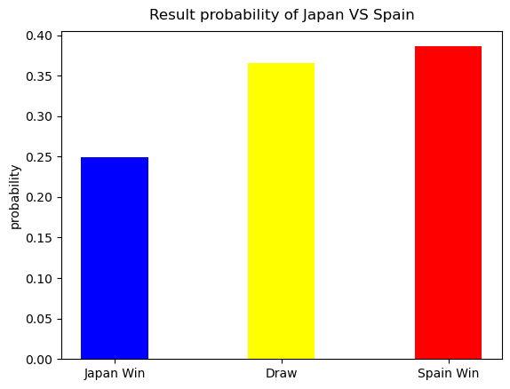

```python
A = Result_df.loc[Result_df['Home Team'] == 'Japan']
A = A.loc[A['Away Team'] == 'Spain']

data = {'Japan Win':A['Home Win rate'].values[0], 'Draw':A['Draw rate'].values[0], 'Spain Win':A['Home Lose rate'].values[0]}
number = list(data.keys())
values = list(data.values())
c = ['blue', 'yellow', 'red']

plt.bar(number, values, color = c, width = 0.4)
plt.title("Result probability of Japan VS Spain", y=1.012)
plt.ylabel("probability", labelpad=3);

plt.show()
```

It is pretty easy to use machine learning method to predic the soccer game right?

The model is very easy and the soccer game can be very uncertained. No one can 100% predict what will happen in a soccer game. But we can try to make a more information contained model which might provide more precise predictions.

If you want, you can include **players' more detailed data** (provided in Player_all) and the **home_away_neutral and other effects** of the game for a **more precise soccer game prediction model**.

### Analyze the model

The neural network models is just like a black box. **But can we get some information from the black-box? Like what position is important for a good soccer team?**

**LIME** and **SHAP** could help with the interpretability.

They are surrogate models. They both **tweak** the input slightly (like we do in sensitivity tests) and **test the changes in prediction**. From the influence, we know how each features is related to the labels.

Let's see how the two models work:

#### LIME

We first name down the 24 feature's meaning (e.g. M4_1 means the forth midfield in team1)

```python
Label_name = ['Team1_Age','Team2_Age','GK_1','RB_1','CB1_1','CB2_1','LB_1','M1_1','M2_1','M3_1','M4_1','F1_1','F2_1','GK_2','RB_2','CB1_2','CB2_2','LB_2','M1_2','M2_2','M3_2','M4_2','F1_2','F2_2']
```

We use a popular game Spain VS Germany as an example of Lime analysis

```python
# Setting the lime explainer
lime_explainer = lime_tabular.LimeTabularExplainer(
    training_data=X_train,
    feature_names=Label_name,
    class_names=['D','L','W'],
    mode='classification'
)

# to Check the game 28 Spain VS Germany
Exam_1 = X_2[27]

# Continue to set the lime explainer
lime_exp = lime_explainer.explain_instance(
    data_row=Exam_1,
    predict_fn=bestmodel.predict_proba,
    num_features=24
)

#plot the result
lime_exp.show_in_notebook(show_table=True)
```

[output not shown]

___(1) The game highly possible will be draw___

___(2) The center line largely influcence the game, especially the midfield.___

___(3) It never says if a team has best player in every position has larger opportunity to win.___

#### SHAP

```python
# Setting the SHAP explainer
explainer = shap.KernelExplainer(bestmodel.predict_proba, X_1)

#Calculate SHAP value
shap_values = explainer.shap_values(X_2)
```

Here, in SHAP, we could display each parameter's influence on the final result by using ___summary plot___ in SHAP. Blue is team 1 wins, pink is draw, brown is team 2 wins:

[figure not shown]

```python
import shap
import matplotlib.pyplot as plt

# Assuming shap_values and X_2 are defined appropriately
# shap_values should be in the shape (num_samples, num_features)
# X_2 should be in the shape (num_samples, num_features)

# Plotting the SHAP summary plot without specifying feature_names
shap.summary_plot(shap_values, X_2,
                  class_names=['D', 'L', 'W'],
                  max_display=24)

plt.show()  # Show the plot
```

Here, from the diagram:

___(1) Ages don't matter that much!___

___(3) Good defense at least could help team to get a draw result.___

We can see each positions' player's potential influence to each game in a the World Cup by using ___force_plot___ in SHAP.

We also see which game could highly possible be a draw game, and could tell which player make the W/L happen.

*Red is draw, Blue is not draw here.*

```python
shap.initjs() #initial jacascript in cell
shap.force_plot(explainer.expected_value[0], shap_values[0], X_1, feature_names=Label_name)
```

[output not shown]

## Practice Queries

### Query 1 - Showing a specific player data

Show the Lionel Messi's information (column FullName == 'Lionel Messi')

[figure not shown]

```python
messi = Player_all.loc[Player_all.FullName == 'Lionel Messi']
messi.head()
```

|  | Name | FullName | Age | Height | Weight | Nationality | Overall | Positions | PreferredFoot | IntReputation | ... | LMRating | CMRating | RMRating | LWBRating | CDMRating | RWBRating | LBRating | CBRating | RBRating | GKRating |
| --- | --- | --- | --- | --- | --- | --- | --- | --- | --- | --- | --- | --- | --- | --- | --- | --- | --- | --- | --- | --- | --- |
| 0 | L. Messi | Lionel Messi | 35 | 169 | 67 | Argentina | 91 | RW | Left | 5 | ... | 91 | 88 | 91 | 67 | 66 | 67 | 62 | 53 | 62 | 22 |

1 rows × 71 columns

### Query 2 - Display a team line up in one game

```python
firstGameLineup = []
for m in range(11):
    location = 'Player'+str(m+1)
    number=Game_62.loc[0][location]
    firstGameLineup.append(Player_all.loc[number]['Name'])
firstGameLineup
```

```
['Y. Bounou',
 'A. Hakimi',
 'R. Saïss',
 'N. Aguerd',
 'A. Masina',
 'R. Mmaee',
 'A. Ounahi',
 'S. Amallah',
 'I. Louza',
 'S. Boufal',
 'C. Awaziem']
```

### Query 3 - Showing a specific game result prediction

Show our model's prediction of Canada VS Morocco in the World Cup, and plot the W/D/L rate in a diagram

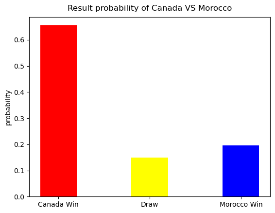

```python
cVm = Result_df.loc[Result_df['Home Team'] == 'Canada']
cVm = cVm.loc[cVm['Away Team'] == 'Morocco']

data = {'Canada Win':cVm['Home Win rate'].values[0], 'Draw':cVm['Draw rate'].values[0], 'Morocco Win':cVm['Home Lose rate'].values[0]}
number = list(data.keys())
values = list(data.values())
c = ['red', 'yellow', 'blue']

plt.bar(number, values, color = c, width = 0.4)
plt.title("Result probability of Canada VS Morocco", y=1.012)
plt.ylabel("probability", labelpad=3);

plt.show()
```

```python
from subprocess import call
call(['python', '-m', 'nbconvert', 'Investigate_a_Dataset.ipynb'])
```

```
4294967295
```

## Authors

Junxing(J.C.) Chen is a Data Science at IBM with strong interests in machine learning and cutting-edge technologies.

## Change Log

| Date (YYYY-MM-DD) | Version | Changed By | Change Description |
| --- | --- | --- | --- |
| 2022-11-01 | 0.1 | Junxing(J.C.) Chen | Create the project |

Copyright © 2022 IBM Corporation. All rights reserved.